# Evidence synthesis for conservation

Matthew Grainger

## Would you restrict drone flights near nesting birds?

A reserve manager asks whether drone flights should be restricted near breeding colonies.

- Which birds and sites have been studied?
- Do flights affect behaviour or breeding success?
- What evidence would justify a restriction at this reserve?

## What makes a synthesis useful?

- It answers a question that someone needs answered.
- It explains how evidence was found, selected and interpreted.
- It shows how study limitations and context affect the conclusion.

## Choose by the output you need

| What do you need? | Approach | Typical output |
| --- | --- | --- |
| Clarify what a broad topic covers | Scoping review | Concepts, definitions and types of evidence |
| Locate evidence clusters and gaps | Systematic map | Searchable study database and summaries of coverage |
| Answer a defined question | Systematic review | Appraised findings and their limitations |
| Estimate an effect across comparable studies | Systematic review with Meta-analysis | Pooled estimate, uncertainty and variation |
| Answer a defined question under a deadline | Rapid review | Focused synthesis with explicit restrictions |

## Scoping review or systematic map?

### Scoping review

**How is drone disturbance defined and measured in bird studies?**

Describe concepts, definitions, outcome measures and types of evidence.

### Systematic map

**Which bird groups, settings and outcomes have been studied in relation to drone disturbance?**

Code each study into a searchable database. Show where studies cluster and where few were found.

## Systematic review

**What effect do recreational drone flights have on nest attendance in colonial seabirds compared with no flights?**

| Question element | Example |
| --- | --- |
| Population | Breeding colonial seabirds |
| Exposure | Recreational drone flights |
| Comparator | Comparable periods or sites without flights |
| Outcome | Time adults spend attending the nest |

## When can you pool results?

- Do the estimates address a shared question?
- Can you express them on a defensible common scale?
- Can you quantify their uncertainty and account for dependence?
- Would a pooled estimate be interpretable across these settings?

**Nest attendance, flushing distance and fledging success answer different questions.**

## A systematic review can synthesise without pooling

- Group studies by outcome, design and setting.
- Tabulate effect estimates and uncertainty where available.
- Explain how bias and differences among studies affect interpretation.

**A tally of statistically significant results depends on study precision and sample size.**

## When time is limited

**The reserve manager needs a briefing in six weeks.**

- Narrow the question to a decision-relevant population and outcome.
- Specify any limits on sources, dates or languages in advance.
- Explain what those limits could miss.

## From question to conclusion

1. Define the question and write a protocol.
2. Search relevant sources and record how you searched.
3. Screen using explicit eligibility criteria.
4. Extract data and appraise study validity as appropriate to the aim.
5. Synthesise and report findings, uncertainty and limitations.

## Exercise

**Which approach would you choose, and what would you deliver?**

**A.** A research funder wants to know which species and outcomes have been studied.

**B.** A reserve manager wants to know whether flights reduce nest attendance.

**C.** A student wants to know how researchers define and measure disturbance.

Pick one. Post your approach and its intended output in the chat.

## Exercise debrief

| Scenario | Starting approach | What you would deliver |
| --- | --- | --- |
| A · Research funder | Systematic map | Study database and coverage by taxon and outcome |
| B · Reserve manager | Systematic review | Appraised findings on nest attendance, pooled if justified |
| C · MSc student | Scoping review | Account of definitions and how outcomes are measured |

**What would you need to know before applying B to your reserve?**

## Does conservation work?

“In two-thirds of cases, conservation either improved the state of biodiversity or at least slowed declines.”

Science

published in 2024

186

included studies

665

intervention trials

7

intervention types

## How convincing is the conclusion?

### Does this evidence show that conservation works?

**A**  
Very confident

**B**  
Fairly confident

**C**  
Uncertain

**D**  
Not confident

## What else would you need to know?

Before accepting—or rejecting—the conclusion, what information would most change your confidence?

Write down one question.

## What initially influenced you?

The journal?  
The word “global”?  
The number of studies?  
The meta-analysis?  
A conclusion you wanted to be true?

## What does the meta-analysis add?

- The authors estimated the **average standardised effect** across the included comparisons.
- They reported **confidence intervals** for the overall estimate and estimates by intervention class.
- Several comparisons could come from the same study. The analysis modelled their clustering within studies.

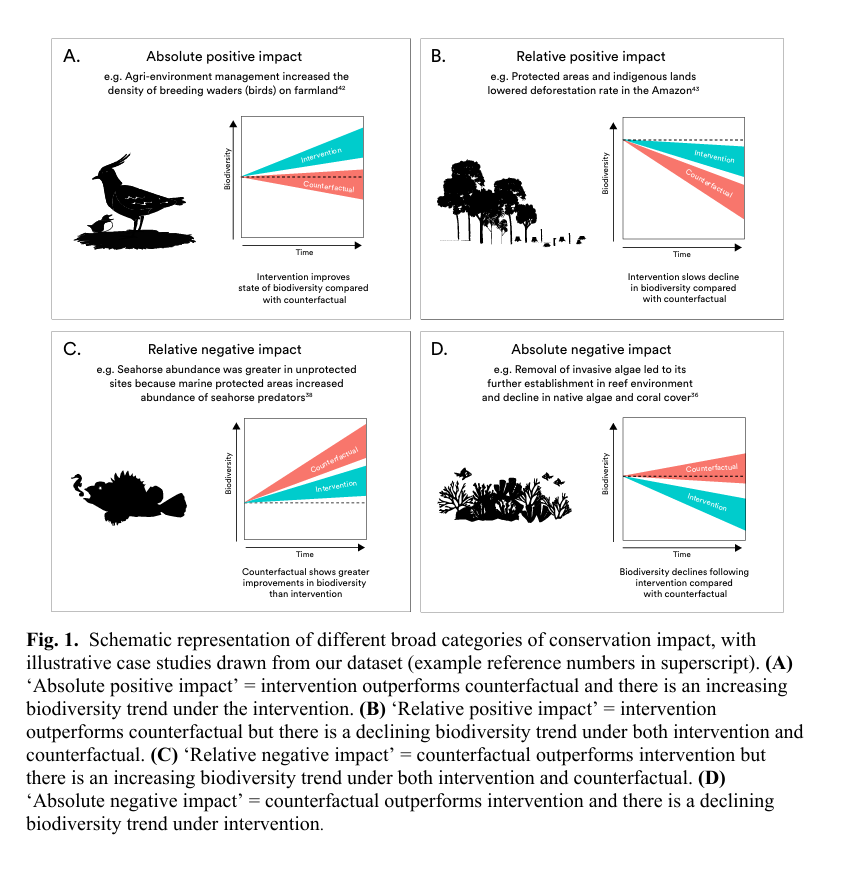

## Would you expect the same benefit at your site?

A manager says, “Our new restoration project has a two-thirds chance of succeeding.” How would you revise that claim?

- Which interventions and outcomes are comparable to the proposed project?
- How similar are the ecological settings and baseline threats?
- How credible are the counterfactuals in the most relevant studies?

## How were the 665 trials classified?

| Outcome relative to the counterfactual | Trials |
| --- | --- |
| Biodiversity improved under conservation | **45.4%** |
| Biodiversity declined more slowly | **20.6%** |
| Biodiversity declined more under intervention | **20.6%** |
| Biodiversity improved more under the counterfactual | **11.6%** |
| No difference | **1.8%** |

Is “two-thirds of trials” an effect estimate, a vote count—or a descriptive classification?

## The evidence is useful—but the target matters

### More defensible

Among eligible, evaluated interventions, conservation often produced better biodiversity trajectories than the selected counterfactuals.

### Not directly estimated

Conservation actions generally have a two-thirds probability of succeeding across actions, places, organisms and circumstances.

The synthesis estimates outcomes in the available evaluated comparisons—not every possible conservation action.

## Vote again

### How confident are you that the study shows “conservation works”?

Very confident Fairly confident Uncertain Not confident

Changing your mind when the evidential basis changes is good scientific judgement.

## Before trusting a claim, pause

Compared with what?

What else could produce this pattern?

What is genuinely replicated?

What is missing—and could it change the story?

## AI in searching and screening

| Stage | Possible assistance | Failure to check for |
| --- | --- | --- |
| Searching | Suggest synonyms and testable database queries | Missed terminology, invented references and opaque coverage |
| Screening | Rank titles and abstracts for human review | Eligible studies ranked low, especially in less familiar subsets |

**Test searches against known eligible studies. Check lower-ranked records before considering any stopping rule.**

## AI in extraction and synthesis

| Stage | Possible assistance | Failure to check for |
| --- | --- | --- |
| Extraction | Suggest structured entries with page or table references | Wrong unit, denominator, comparator or sample size |
| Synthesis | Draft text from a verified evidence table | Causal overstatement, flattened differences or unsupported claims |

**Trace extracted values and substantive claims back to the evidence.**

## Spot the extraction error

**Hypothetical paper:** Twelve colonies each received two drone flights. Nest attendance was recorded after each flight.

**AI extraction:** Sample size = 24 independent colonies.

What would you correct, and what would you check next?

## Decide how you will check AI assistance

- Define the specific task and what a consequential error would be.
- Compare outputs with independently checked examples from your review.
- Decide which outputs require human verification.
- Record the tool, version, role, checks and how errors were handled.

**The review team is accountable for the methods and findings.**

## Further reading

- [CEE Guidelines · Choosing a synthesis approach](https://collaborationenvironmentalevidence.github.io/CEE_guidelines/Chapter_2.html)
- [ROSES · Reporting systematic reviews and maps](https://environmentalevidence.org/roses/)
- [RAISE · Responsible AI use in evidence synthesis](https://osf.io/fwaud/overview)
- [Joint position statement on AI in evidence synthesis](https://link.springer.com/article/10.1186/s13750-025-00374-5)